# Creating new variables

Hector Antonio Vazquez Brust

October 9, 2015

## Boston neighborhoods: A more nuanced view on assessed value

This time we’ll create some new variables to fix problems with our dataset, and also to facilitate a deeper analysis.

As we’ve seen before, our dataset holds many properties whose year of construction is listed as zero:

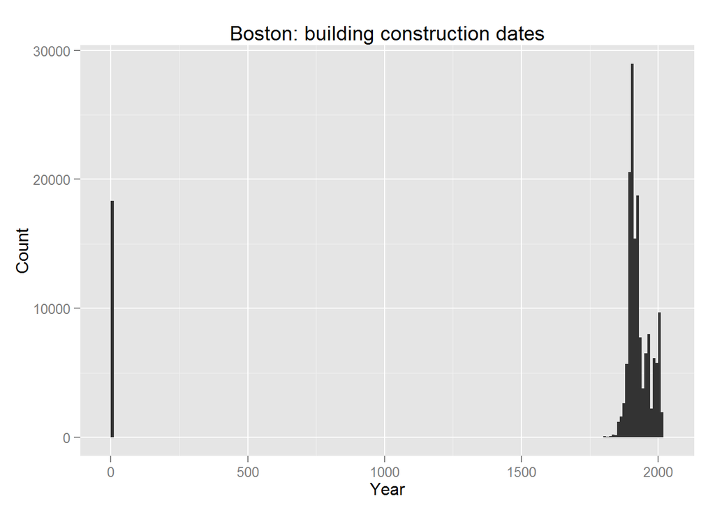

```r
ggplot(TAdata, aes(x = YR_BUILT)) + geom_histogram(binwidth = 10) + ggtitle("Boston: building construction dates") + labs(x="Year",y="Count")
```

We will fix that by creating a “revised” variable, which will hold a “NA” where the YR_BUILT column lists a “0”, and otherwise it will reflect the construction year:

```r
TAdata <- transform(TAdata, YR_BUILT_REVISED = ifelse(YR_BUILT == 0, NA, YR_BUILT))
```

Let’s check how it looks now:

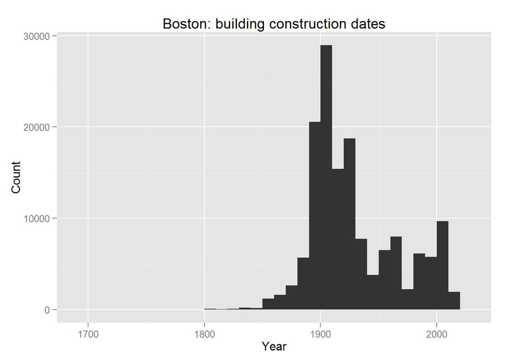

```r
ggplot(TAdata, aes(x = YR_BUILT_REVISED)) + geom_histogram(binwidth = 10) + ggtitle("Boston: building construction dates") + labs(x="Year",y="Count")
```

Good; the “0” dates are gone. The plot has the x axis starting at 1700 -could it be that a few extant buildings from that time are being represented? Yes, that’s the case:

```r
head(arrange(TAdata[c('ST_NUM', 'ST_NAME', 'ST_NAME_SUF', 'ZIPCODE', 'YR_BUILT_REVISED')], YR_BUILT_REVISED))
```

```
##   ST_NUM   ST_NAME ST_NAME_SUF ZIPCODE YR_BUILT_REVISED
## 1  21 23 GREENVIEW          AV    2130             1700
## 2    168  SYCAMORE          ST    2131             1710
## 3    266    POPLAR          ST    2131             1725
## 4  15 17 PEACEABLE          ST    2135             1725
## 5      1    COMMON          ST    2129             1752
## 6      2    COMMON          ST    2129             1752
```

(it must be mentioned that I took a look at a few of those buildings in Google Street View, and they do not look that old at all… maybe we’ll investigate further in the future)

Next, we will create two additional values, that will help us provide a more nuanced analysis of assessed land and building values in Boston, by giving us values normalized by total land area or gross area.

“AV_LAND_PER_SF” will tell us the assessed value per square foot of a parcel lot:

```r
TAdata <- transform(TAdata, AV_LAND_PER_SF = ifelse((AV_LAND != 0 & LAND_SF != 0), AV_LAND / LAND_SF, NA))
```

And “AV_BLDG_PER_SF” will give us the assessed value per square foot of a building:

```r
TAdata <- transform(TAdata, AV_BLDG_PER_SF = ifelse((AV_BLDG != 0 & GROSS_AREA != 0), AV_BLDG / GROSS_AREA, NA))
```

How can we use these new variables?

Well, if we compare the total amount of assessed value per neighborhood, we find the downtown area on top, and Hyde Park at the bottom:

```r
BRA_PD.value <- ddply(TAdata[(!is.na(TAdata$BRA_PD) & !is.na(TAdata$AV_BLDG)), ], .(BRA_PD), summarise, bldg.value = sum(as.numeric(AV_BLDG)/1000000000), land.value = sum(as.numeric(AV_LAND)/1000000000))

arrange(BRA_PD.value, desc(bldg.value + land.value))
```

```
##                  BRA_PD bldg.value land.value
## 1               Central 44.9286173  12.322881
## 2        Fenway/Kenmore 33.1777086  11.052647
## 3           East Boston 19.5678924  22.795224
## 4      Allston/Brighton 27.4675421  14.464064
## 5  Back Bay/Beacon Hill 19.5349884   5.433032
## 6          South Boston 14.6486152   8.748036
## 7         Jamaica Plain 15.6877432   4.582938
## 8             South End 11.1079671   3.176731
## 9      North Dorchester  5.9516680   3.821066
## 10             Mattapan  5.0786037   3.088273
## 11          Charlestown  5.6468987   2.356018
## 12         West Roxbury  4.6110990   2.537452
## 13              Roxbury  3.8052696   1.901329
## 14     South Dorchester  3.5989092   1.854839
## 15           Roslindale  2.9080772   1.532717
## 16            Hyde Park  2.2990903   1.971368
## 17                       0.0049947   0.000000
```

(figures expressed in billions of USD)

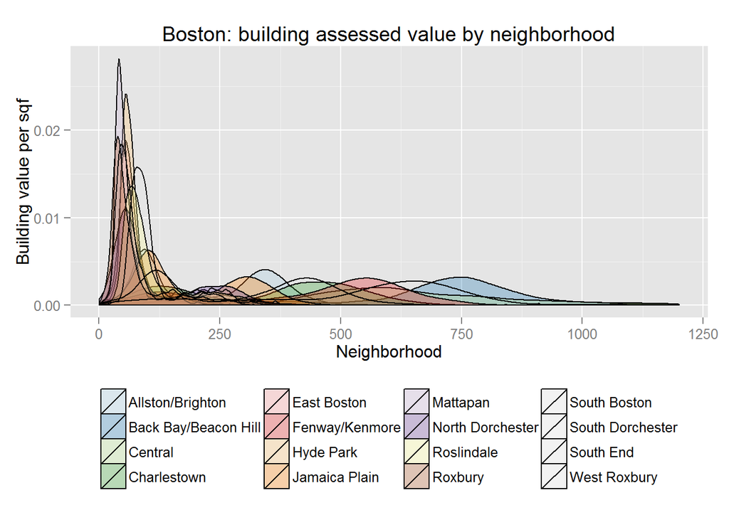

```r
ggplot(TAdata[TAdata$BRA_PD != '' & TAdata$AV_BLDG_PER_SF > 1,], aes(AV_BLDG_PER_SF, fill = BRA_PD)) + geom_density(alpha = 0.3)  + xlim(1,1200) + scale_fill_brewer(name="Neighborhood", palette="Paired") + guides(fill=guide_legend(ncol=4)) + theme(legend.title=element_blank(), legend.direction ="vertical",legend.position = "bottom") + ggtitle("Boston: building assessed value by neighborhood") + labs(x="Neighborhood",y="Building value per sqf")
```

Back Bay/Beacon Hill is the area where the building value tends to be higher, as normalized by area; it’s hard to tell which neighborhoods come last, since the density curves are superimposing. A box plot may be easier to read:

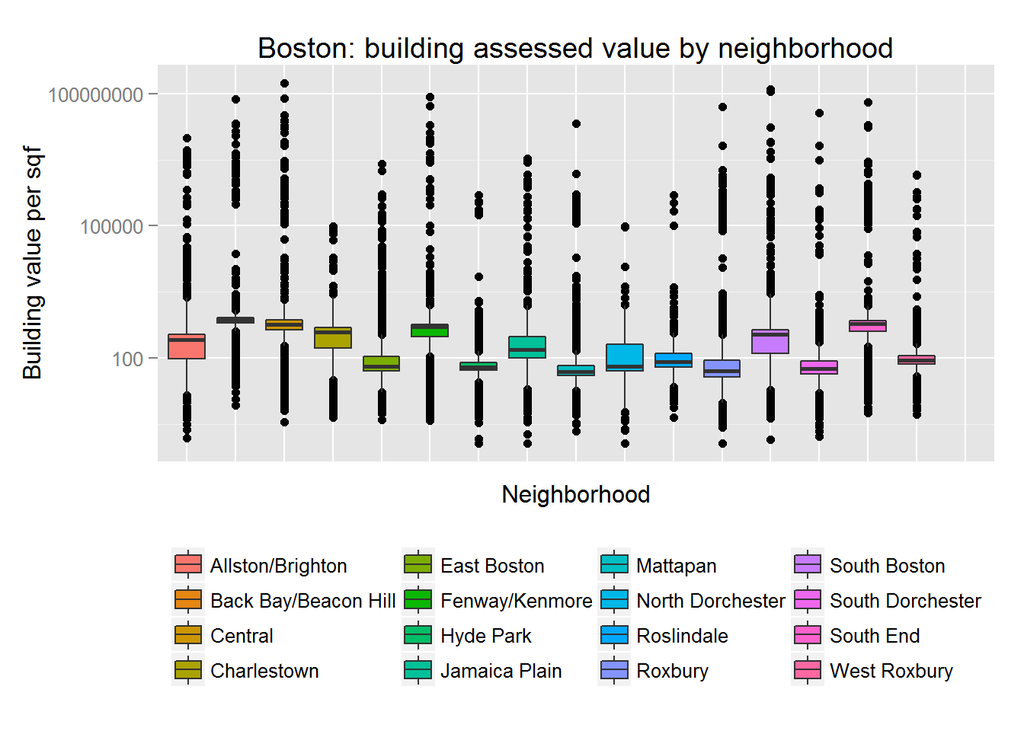

```r
ggplot(TAdata[TAdata$BRA_PD != '' & TAdata$AV_BLDG_PER_SF > 1,], aes(x = BRA_PD, y = AV_BLDG_PER_SF, fill = BRA_PD)) + geom_boxplot() + scale_y_log10() + guides(fill=guide_legend(ncol=4)) + theme(legend.title=element_blank(), axis.ticks.x = element_blank(), axis.text.x = element_blank(), legend.direction ="vertical",legend.position = "bottom") + ggtitle("Boston: building assessed value by neighborhood") + labs(x="Neighborhood",y="Building value per sqf")
```

That helps (slightly). At least we can tell that Mattapan and Roxbury come last.

And what about land value?

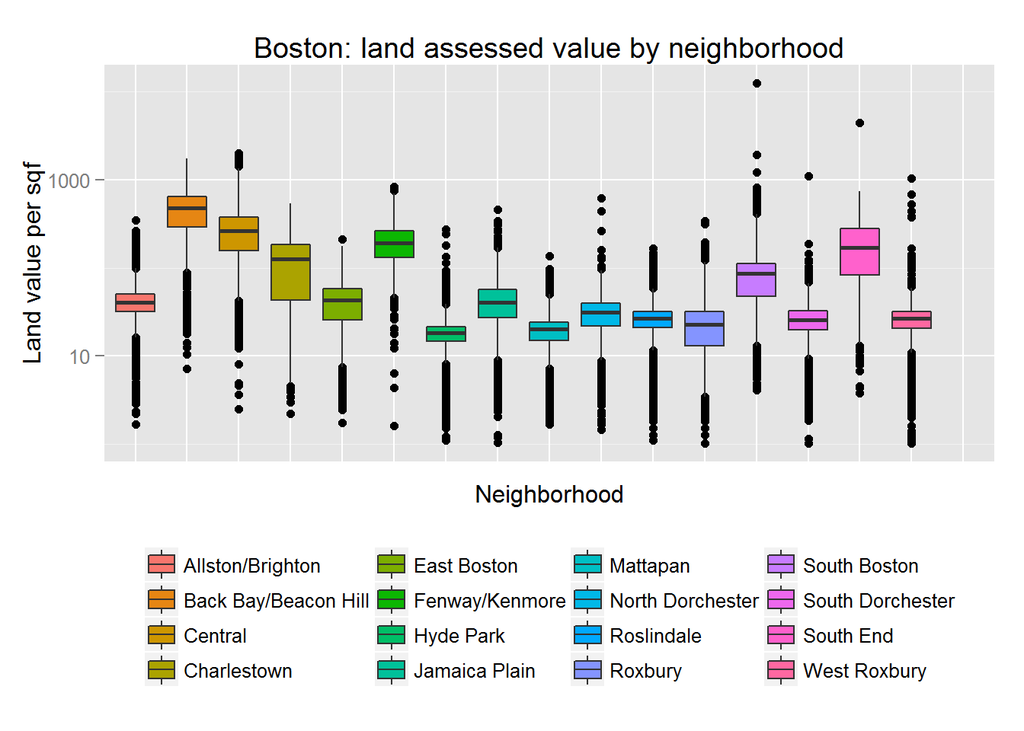

```r
ggplot(TAdata[TAdata$BRA_PD != '' & TAdata$AV_LAND_PER_SF > 1,], aes(x = BRA_PD, y = AV_LAND_PER_SF, fill = BRA_PD)) + geom_boxplot() + scale_y_log10() + guides(fill=guide_legend(ncol=4)) + theme(legend.title=element_blank(), axis.ticks.x = element_blank(), axis.text.x = element_blank(), legend.direction ="vertical",legend.position = "bottom") + ggtitle("Boston: land assessed value by neighborhood") + labs(x="Neighborhood",y="Land value per sqf")
```

Again, Back Bay/Beacon Hill is the area where values are higher than in the rest of the city. Hyde Park (followed by Mattapan) is where the values tend to be lower.

This illustrates how adding additional variables that combine the information of others in useful ways, can help us arrive at a better understanding of of our data.